# NYPD Shooting Data Analysis

J. Bakovich

2026-02-17

## Introduction

This document is an analysis of shooting data presented by the New York Police Department, beginning in the year 2006 (the link for the data is provided [here](https://data.cityofnewyork.us/api/views/98wc-x49t/rows.csv?accessType=DOWNLOAD)). This document works through importing, tidying, and analyzing/modeling the data, as well as providing some potential source of bias.

This document attempts to answer the following questions:

1. Are shooting number different across all of the boroughs of New York? And if so, by how much?
2. How do the number of shootings compare across different hours of the day? Does it follow a linear pattern?

## Shooting Data Summary

Below is a snapshot of the data that was imported. It breaks down different shooting incidents through their date/time of occurrence and location (borough, precinct, latitude/longitude, etc.).

```
##   INCIDENT_KEY        OCCUR_DATE          OCCUR_TIME
##  Min.   :298756515   Length:769         Min.   :00:04:00.000000
##  1st Qu.:304666142   Class :character   1st Qu.:06:04:00.000000
##  Median :307892883   Mode  :character   Median :16:42:00.000000
##  Mean   :307309341                      Mean   :14:02:29.882965
##  3rd Qu.:310937083                      3rd Qu.:20:35:00.000000
##  Max.   :313716449                      Max.   :23:59:00.000000
##      BORO           LOC_OF_OCCUR_DESC     PRECINCT      JURISDICTION_CODE
##  Length:769         Length:769         Min.   :  5.00   Min.   :0.0000
##  Class :character   Class :character   1st Qu.: 43.00   1st Qu.:0.0000
##  Mode  :character   Mode  :character   Median : 50.00   Median :0.0000
##                                        Mean   : 59.93   Mean   :0.2952
##                                        3rd Qu.: 75.00   3rd Qu.:0.0000
##                                        Max.   :122.00   Max.   :2.0000
##  LOC_CLASSFCTN_DESC LOCATION_DESC      STATISTICAL_MURDER_FLAG
##  Length:769         Length:769         Length:769
##  Class :character   Class :character   Class :character
##  Mode  :character   Mode  :character   Mode  :character
##
##
##
##  PERP_AGE_GROUP       PERP_SEX          PERP_RACE         VIC_AGE_GROUP
##  Length:769         Length:769         Length:769         Length:769
##  Class :character   Class :character   Class :character   Class :character
##  Mode  :character   Mode  :character   Mode  :character   Mode  :character
##
##
##
##    VIC_SEX            VIC_RACE           X_COORD_CD        Y_COORD_CD
##  Length:769         Length:769         Min.   : 939190   Min.   :148073
##  Class :character   Class :character   1st Qu.:1000565   1st Qu.:185083
##  Mode  :character   Mode  :character   Median :1008932   Median :218949
##                                        Mean   :1009882   Mean   :215165
##                                        3rd Qu.:1016886   3rd Qu.:244278
##                                        Max.   :1057339   Max.   :266422
##     Latitude       Longitude      New Georeferenced Column
##  Min.   : 0.00   Min.   :-74.16   Length:769
##  1st Qu.:40.67   1st Qu.:-73.94   Class :character
##  Median :40.76   Median :-73.91   Mode  :character
##  Mean   :40.17   Mean   :-72.85
##  3rd Qu.:40.84   3rd Qu.:-73.88
##  Max.   :40.90   Max.   :  0.00
```

## Cleaning/Tidying the Data

To tidy and clean the data into the format that I desire (and eliminating bad data), I did the following:

- Converted the occurrence data into a date object
- Created new columns that describe the date in different ways: year, hour, day_of_week
- Filtered out rows that did not have occurrence dates or boroughs listed
- Selected only the rows that I care to interpret

In doing this cleanup, I not only eliminated bad data, but I also mutated the data with only columns that I desire.

How I did this is shown in the code block below:

```r
shootings_clean <- shooting_data %>%
  rename_with(tolower) %>%
  mutate(
    occur_date = as.Date(occur_date, format = "%m/%d/%Y"),
    year = format(occur_date, "%Y"),
    hour = as.integer(substr(occur_time, 1, 2)),
    day_of_week = weekdays(occur_date)
  ) %>%
  filter(!is.na(occur_date), !is.na(boro), !is.na(hour)) %>%
  select(-c("incident_key", "loc_of_occur_desc", "precinct","jurisdiction_code",
            "loc_classfctn_desc", "location_desc", "x_coord_cd", "y_coord_cd",
            "latitude","longitude"))
```

## Visualizing the Data

I chose to visualize the data in multiple ways: shootings by borough and shootings by hour as they are related to the day of the week.

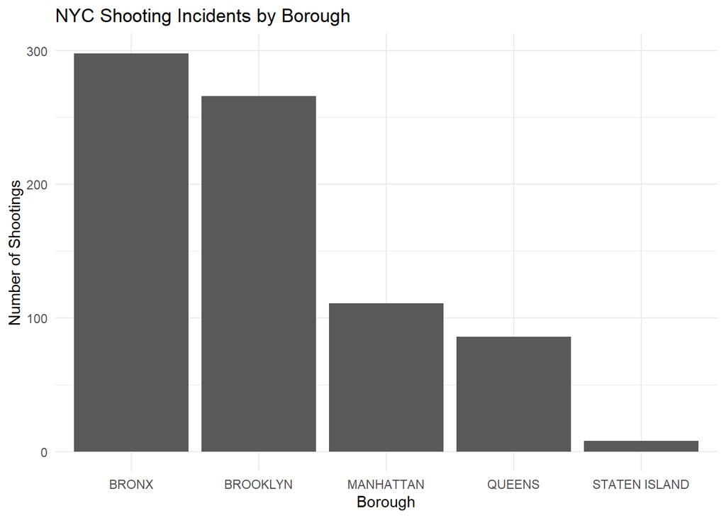

```r
shootings_by_boro <- shootings_clean %>%
  count(boro, sort = TRUE)

ggplot(shootings_by_boro, aes(x = boro, y = n)) +
  geom_col() +
  labs(
    title = "NYC Shooting Incidents by Borough",
    x = "Borough",
    y = "Number of Shootings"
  ) +
  theme_minimal()
```

The graph below displays a heat map of the day of the week relative to the hour of the day. The brighter colors symbolize higher numbers of shootings on average, while dark colors relate to less shootings. In looking at the graph, one can interpret that more shootings occur on weekends, especially more doing the nighttime hours of the day.

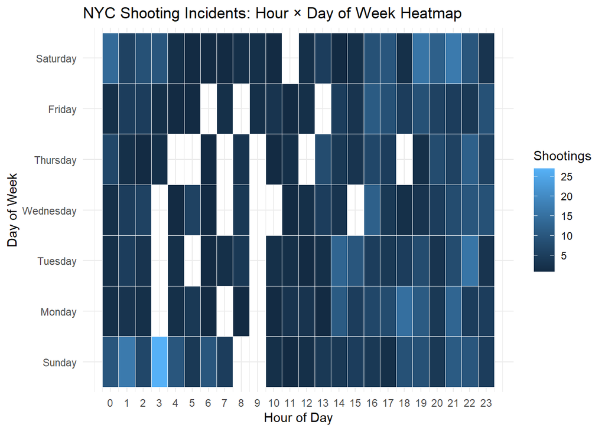

```r
shootings_heatmap <- shootings_clean %>%
  count(day_of_week, hour)

shootings_heatmap$day_of_week <- factor(
  shootings_heatmap$day_of_week,
  levels = c("Sunday", "Monday", "Tuesday", "Wednesday",
             "Thursday", "Friday", "Saturday")
)

ggplot(shootings_heatmap, aes(x = hour, y = day_of_week, fill = n)) +
  geom_tile(color = "white") +
  scale_x_continuous(breaks = 0:23) +
  labs(
    title = "NYC Shooting Incidents: Hour × Day of Week Heatmap",
    x = "Hour of Day",
    y = "Day of Week",
    fill = "Shootings"
  )+
  theme_minimal()
```

## Modeling the Data

The graph below shows predictive analysis as a linear regression model for shooting incidents across NY as related to the hour of the day, shifted to show that as the day progresses into the night, shootings increase. However, the graph shows that the hour of the day is not quite linearly related to the number of shootings and more parabolic. Nonetheless, the data does show that through certain hours of the night, shootings significantly increase, while shootings during the day happen less.

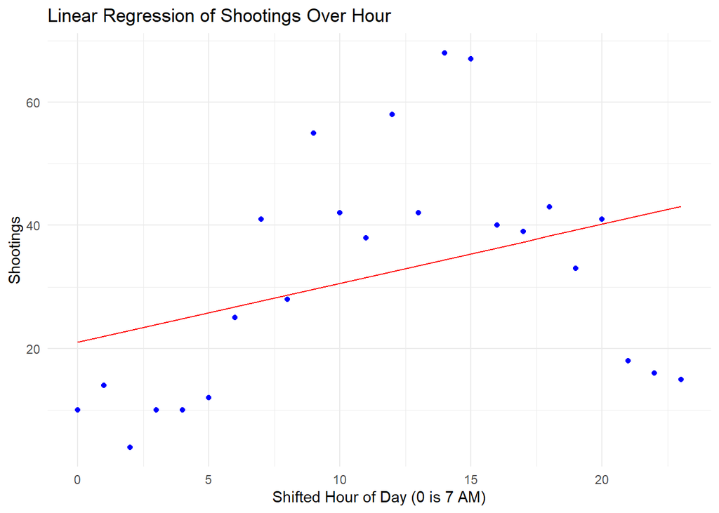

```r
shootings_hour <- shootings_clean %>%
  count(hour) %>%
  mutate(shifted_hour = (hour-7) %%24 )

model <- lm(n ~ shifted_hour, data=shootings_hour)

shootings_hour_pred <- shootings_hour %>% mutate(pred = predict(model))

shootings_hour_pred %>% ggplot() +
  geom_point(aes(x = shifted_hour, y = n), color="blue") +
  geom_line(aes(x = shifted_hour, y = pred, group = 1), color="red")+
  labs(
    title = "Linear Regression of Shootings Over Hour",
    x = "Shifted Hour of Day (0 is 7 AM)",
    y = "Shootings",
  )+
  theme_minimal()
```

## Conclusion / Source of Bias

Through analyzing the data, a significant source of bias could come from the reporting side of the incidents. This data only contextualizes shooting incidents that were reported. Therefore, if there are larger amount of misreporting or failure to report in certain communities (or even boroughs), then the data would be skewed away from shootings in those communities. Thus, bias is present in the data favoring shootings in communities that are better are reporting (and doing so accurately).